# LSTM Sentiment Analyzer

## Classifying sentiment of 1 Million Tweets using LSTM & Pre-trained Glove Embeddings in Tensorflow

### `Author`: Aditya Patel

`Dataset`: https://www.kaggle.com/kazanova/sentiment140  
`Techniques used`: LSTM, Transfer Learning Pre-trained Glove Embeddings in Tensorflow

Step 1: Preprocessing Dataset

```
 Dataset is a .csv file. Extracted text strings and labels (i.e. sentiment values) from it. Created 2 lists, one is a list of sentences where each sentence is a long string and 2nd list is a list of labels i.e. target values. The original labels were 0 and 4 indicating -ve and +ve sentiment. These will be converted into 0 and 1 for binary classification
```

Step 2: Create Corpus dictionary e.g. corpus['please'] = 234

```
 Instantiate Keras Tokenizer and fit it on the list of 1 Million sentences/tweets created above. Thus, 1 Million tweets are tokenized. The number of tokens is around 1/2 million. Tokenization means converting words into numbers. Then I pad them so that all tweets have 30 words to maintain consisten in order to feed into a neural network.
```

Step 3: Create embedding matrix weights to feed into Neural Net.

[output not shown]

Step 4: Create a Neural Net

```
 1st layer will be Embedding. I'm feeding a tweet to it. Tweet has 30 words i.e. 30 sequence of numbers. Each word (i.e. its number) will be converted into a vector of dimension 100. So the o/p of the embedding layer will be 30 x 100. Next will be Dropout, Conv1D, MaxPooling1D, LSTM and output layer will be Dense with 1 neuron and sigmoud output since it's binary classification
```

Step 5: Train neural net and see performance on test set

### Dataset looks like...

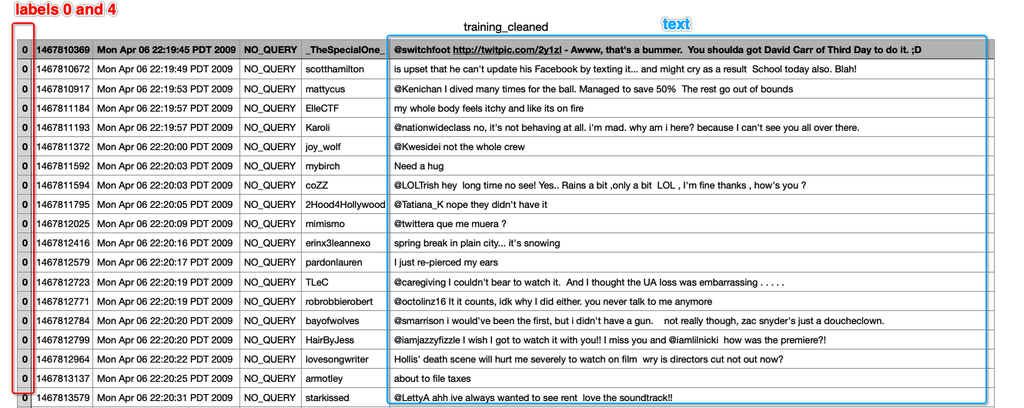

```python
import tensorflow as tf
import csv, random, numpy as np, pandas as pd

from tensorflow.keras.preprocessing.text import Tokenizer
from tensorflow.keras.preprocessing.sequence import pad_sequences
from tensorflow.keras.layers import Dense, LSTM, Conv1D, MaxPooling1D, Dropout, Embedding
```

Dimension of embedding/feature must be 100 as i'm using GloVe embedding pre-trained weights. This could be 20 or 30 or 4 or 500, if i had chosen to train them. But since i am using ready made pretrained weights, i'll wanna have dimension of each word to be a vector of dimension 100

```python
#     --------hyperparameters---------
embedding_dim = 100
max_length = 30         # ek tweet/sentence ma 30 words max
trunc_type='post'       # lamba sentence ne kapva
padding_type='post'     # short sentence ne extend kar after its end
oov_tok = "???"         # any symbol can be used instead of ??? as long as it is unique
training_size=int(1e6)  # indicates how many tweets to train on i.e form a corpus on
test_portion=0.4        # 40% is good test of generalizability
```

Note above 40% of tweets are unseen which is a good test of robustness and generalizability

### Steps 1 and 2

```python
num_sentences = 0
df = pd.read_csv('training_cleaned.csv', header = None)
df.columns = ['sentiment','ids','date','flag','user','text']
cols = ['sentiment', 'text', 'ids']
df = df[cols]
```

With the way the .csv dataset is, the first few hundred thousand reviews are all negative i.e. 0, so must shuffle them

```python
df = df.sample(frac=1)     # to shuffle
sentences = df['text'].tolist()[0:training_size]
labels = df['sentiment'].tolist()[0:training_size]
num_sentences = len(sentences)
labels = [1 if i ==4 else 0 for i in labels]      # super important to convert label 4 to 1. Binary classifier does not recognize 4

tokenizer = Tokenizer(oov_token=oov_tok)
tokenizer.fit_on_texts(sentences)            # Fit tokenizer on list of 1 Million tweets

word_index = tokenizer.word_index   # this creates a dictionary e.g. word_index['please'] = 235
vocab_size=len(word_index)          # this is around 500K tokens

sequences = tokenizer.texts_to_sequences(sentences)
padded = pad_sequences(sequences, maxlen=max_length, padding=padding_type, truncating=trunc_type)

split = int(test_portion * training_size)

test_sequences = padded[0:split]                 # 0 to 400K
test_labels = labels[0:split]                    # 400K to 1 Million
training_sequences = padded[split:training_size]
training_labels = labels[split:training_size]
```

### Step 3

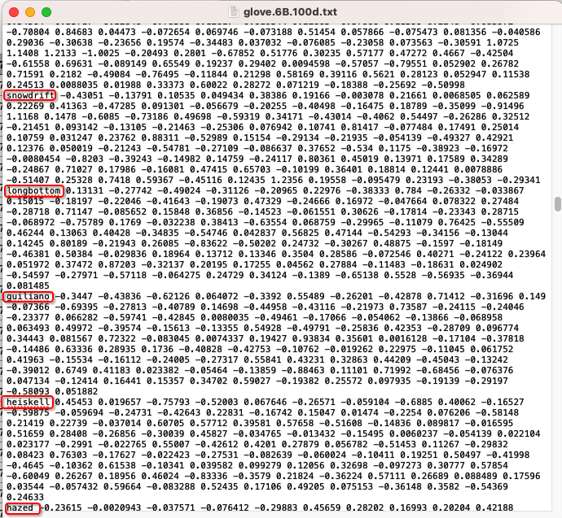

```python
"""Note this is the 100 dimension version of GloVe from Stanford.
So "each" word is a vector [_,_,_,..100 elements]"""

embeddings_dictionary= {}
with open('glove.6B.100d.txt') as f:
    for line in f.readlines():
        values = line.split()
        word = values[0]
        vector = np.array(values[1:], dtype = float)   # Each vector has dimension 100
        embeddings_dictionary[word] = vector

embeddings_matrix = np.zeros((vocab_size+1, embedding_dim))  # vocab_size+1 'cos numbers in vocab start from 1 not 0
for word, number in word_index.items():
    embedding_vector = embeddings_dictionary.get(word);
    if embedding_vector is not None:
        embeddings_matrix[number] = embedding_vector
```

### Step 4

```python
model = tf.keras.Sequential([
    Embedding(vocab_size+1,          # this number of units
              embedding_dim,         # this is exactly like kernel size
              input_length=max_length,
              weights=[embeddings_matrix],
              trainable=False),
    Dropout(0.2),
    Conv1D(64, 5, activation='relu'),
    MaxPooling1D(pool_size=4),
    LSTM(64),
    Dense(1, activation='sigmoid')
])
model.compile(loss='binary_crossentropy',optimizer='adam',metrics=['accuracy'])
model.summary()

num_epochs = 10

X_train= training_sequences
y_train = np.array(training_labels)
X_test = test_sequences
y_test = np.array(test_labels)

history = model.fit(X_train, y_train, epochs=num_epochs, validation_data=(X_test, y_test), verbose=2)

print("Training Complete")
```

```
2021-12-19 01:33:59.927010: I tensorflow/core/platform/cpu_feature_guard.cc:151] This TensorFlow binary is optimized with oneAPI Deep Neural Network Library (oneDNN) to use the following CPU instructions in performance-critical operations:  AVX2 FMA
To enable them in other operations, rebuild TensorFlow with the appropriate compiler flags.
```

```
Model: "sequential"
_________________________________________________________________
 Layer (type)                Output Shape              Param #
=================================================================
 embedding (Embedding)       (None, 30, 100)           50371000

 dropout (Dropout)           (None, 30, 100)           0

 conv1d (Conv1D)             (None, 26, 64)            32064

 max_pooling1d (MaxPooling1D  (None, 6, 64)            0
 )

 lstm (LSTM)                 (None, 64)                33024

 dense (Dense)               (None, 1)                 65

=================================================================
Total params: 50,436,153
Trainable params: 65,153
Non-trainable params: 50,371,000
_________________________________________________________________
18750/18750 - 139s - loss: 0.5108 - accuracy: 0.7449 - val_loss: 0.4681 - val_accuracy: 0.7758 - 139s/epoch - 7ms/step
18750/18750 - 157s - loss: 0.4764 - accuracy: 0.7690 - val_loss: 0.4575 - val_accuracy: 0.7812 - 157s/epoch - 8ms/step
18750/18750 - 145s - loss: 0.4652 - accuracy: 0.7764 - val_loss: 0.4488 - val_accuracy: 0.7883 - 145s/epoch - 8ms/step
18750/18750 - 159s - loss: 0.4593 - accuracy: 0.7803 - val_loss: 0.4494 - val_accuracy: 0.7884 - 159s/epoch - 8ms/step
18750/18750 - 132s - loss: 0.4550 - accuracy: 0.7829 - val_loss: 0.4466 - val_accuracy: 0.7896 - 132s/epoch - 7ms/step
18750/18750 - 141s - loss: 0.4517 - accuracy: 0.7855 - val_loss: 0.4434 - val_accuracy: 0.7908 - 141s/epoch - 8ms/step
18750/18750 - 134s - loss: 0.4497 - accuracy: 0.7859 - val_loss: 0.4436 - val_accuracy: 0.7913 - 134s/epoch - 7ms/step
18750/18750 - 129s - loss: 0.4477 - accuracy: 0.7874 - val_loss: 0.4420 - val_accuracy: 0.7925 - 129s/epoch - 7ms/step
18750/18750 - 123s - loss: 0.4466 - accuracy: 0.7886 - val_loss: 0.4468 - val_accuracy: 0.7875 - 123s/epoch - 7ms/step
18750/18750 - 139s - loss: 0.4456 - accuracy: 0.7890 - val_loss: 0.4420 - val_accuracy: 0.7923 - 139s/epoch - 7ms/step
Training Complete
```

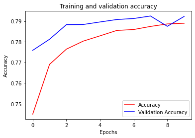

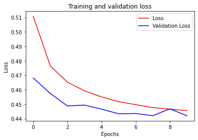

```python
import matplotlib.image  as mpimg
import matplotlib.pyplot as plt

#-----------------------------------------------------------
# Retrieve a list of list results on training and test data
# sets for each training epoch
#-----------------------------------------------------------
acc=history.history['accuracy']
val_acc=history.history['val_accuracy']
loss=history.history['loss']
val_loss=history.history['val_loss']

epochs=range(len(acc)) # Get number of epochs

#------------------------------------------------
# Plot training and validation accuracy per epoch
#------------------------------------------------
plt.plot(epochs, acc, 'r')
plt.plot(epochs, val_acc, 'b')
plt.title('Training and validation accuracy')
plt.xlabel("Epochs")
plt.ylabel("Accuracy")
plt.legend(["Accuracy", "Validation Accuracy"])

plt.figure()

#------------------------------------------------
# Plot training and validation loss per epoch
#------------------------------------------------
plt.plot(epochs, loss, 'r')
plt.plot(epochs, val_loss, 'b')
plt.title('Training and validation loss')
plt.xlabel("Epochs")
plt.ylabel("Loss")
plt.legend(["Loss", "Validation Loss"])

plt.figure()


# Expected Output
# A chart where the validation loss does not increase sharply!

#%%
```

Accuracy and Loss seem good. Rise and fall together and overfitting is not a problem. The classifier had not seen 40% of 1 Million tweets and yet did a decent job.

# ----------------END---------------------